# Workshop module 1: magnetostatic field

## True or false (and why)

1. Magnetic force does not work
2. It is possible for a test charge to get through a magnetic field without experiencing any magnetic force.
3. There is no net force acting on a magnetic dipole in a uniform magnetic field.
4. The magnetic moment of a small circuit loop of area $A$ and current $I$ is $\mu=I/A$.
5. The magnetic field due to a long conducting wire decreases as the square of the distance.
6. It is possible to determine the drift velocity using the Hall effect.
7. Ampere's law is satisfied only for charge distributions with high degree of symmetry.
8. Magnetic susceptibility is always positive.
9. Diagmagnetisim is due to induced magnetic moments.
10. The magnetic field created by a ferromagnetic material is proportional to an externally applied mangnetic field.
11. The trajectory of a moving charged particle is always perpendicular to the magnetic field lines.

## Questions

1. In a Hall-effect experiment, is it possible that no transverse potential difference will be observed? Under what circumstances might this happen?
2. Hall-effect voltages are much greater for relatively poor conductors (such as germanium) than for good conductors (such as copper), for comparable currents, fields, and dimensions. Why?
3. In order to maximize the magnetic moment using a given wire of lenth $L$, is it better to build a unique circular loop or many of them but smaller ones?
4. Infinitely long wires do not exist. Under what circumstances is it justified to state that a particular wire is long enough to be considered infinite?
5. Two parallel conductors carrying current in the same direction attract each other. If they are permitted to move toward each other, the forces of attraction do work. From where does the energy come? Does this contradict the assertion that magnetic forces on moving charges do no work?
6. Describe what's happening in the following experiment.

```python
from IPython.display import YouTubeVideo
YouTubeVideo('N9JKioC4E2k')
```

[video not shown]

## Problems

### Problem 1

We have three infinitely long wires parallel to each other as indicated in the figure. Calculate

- a) The force per unit length experienced by conductor number $2$.
- b) The equilibrium position of conductor $2$ if it could freely move on the plane defined by the three wires.
- c) It such equilibrium stable?

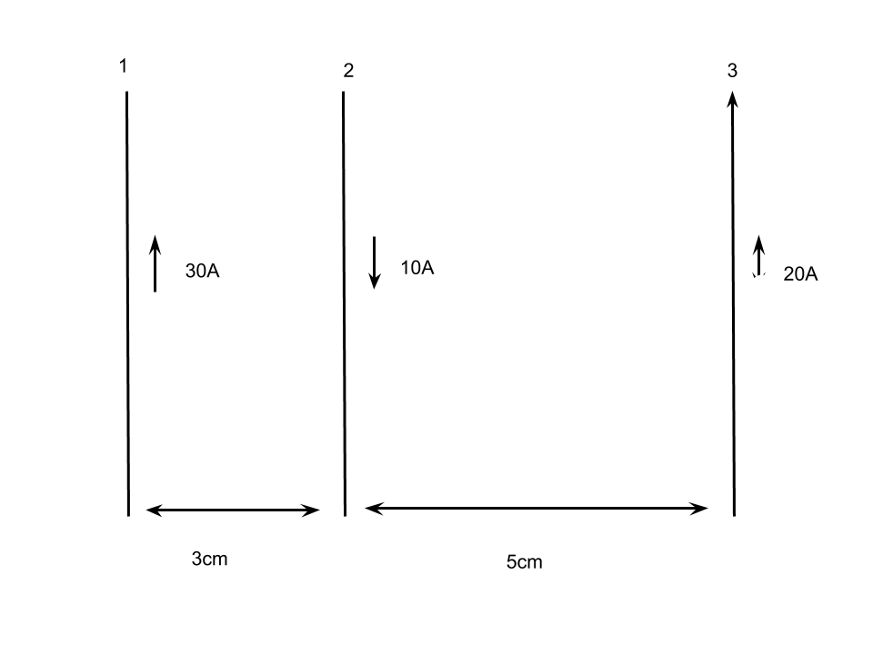

### Problem 2

Two concentric circular loops of wire lie on a tabletop, one inside the other. The inner wire has a diameter of 20.0 cm and carries a clockwise current of 12.0 A, as viewed from above, and the outer wire has a diameter of 30.0 cm. What must be the magnitude and direction (as viewed from above) of the current in the outer wire so that the net magnetic field due to this combination of wires is zero at the common center of the wires?

### Problem 3

A solid conductor with radius $a$ is surrounded by a conducting tube with inner radius $b$ and out radius $c$ as shown in the figure. The central conductor and tube carry equal currents $I$ in opposite directions and uniformly distributed over their cross sections. Find the magnetic field in every point of space.

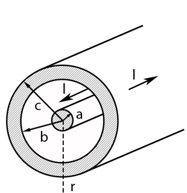

### Problem 4

Find the current needed to achieve such a magnetic field of 37.2 T with

- a) 2.00 cm from a long, straight wire.
- b) at the center of a circular coil of radius 42.0 cm that has 100 turns.
- c) near the center of a solenoid with radius 2.40 cm, length 32.0 cm, and 40,000 turns.

### Problem 5

A toroidal solenoid with 400 turns of wire and a mean radius of 6.0 cm carries a current of 0.25 A. The relative permeability of the core is 80. What is the magnetic field in the core?

### Problem 6

The figure shows a silver ribbon with $z_1=11.8mm$ and $y_1=0.23mm$ carrying a current of $120 A$ in the positive x-direction. The ribbon lies in a uniform magnetic field in the positive y-direction, with magnitude 0.95 T.

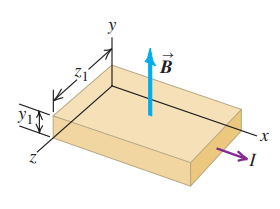

Knowing that for silver there are $5.85\times 10^{28}$ free electrons per cubic meter, find

- a) the drift velocity of the electrons in the x-direction.
- b) the magnitude and direction of the electric field in the z-direction due to the Hall effect.
- c) the Hall emf.

### Problem 7

Imagine a strip of an unknown metal of the same dimensions as those of problem 6. When the magnetic field is $2.29 T$ and the current is $78.0 A$, the Hall emf is found to be $131\mu V$. What is the density of free electrons in the unknown metal according to the Hall effect?